# Reading Dataset and Feature Elimination

## Early stopping

As mentioned earlier, loss function for validation set stops decreasing and start increasing after certain epoch. We can try to catch this moment and stop training NN to avoid overfitting

```python
early_stop_cb = ks.callbacks.EarlyStopping(
    monitor="val_loss",
    min_delta=0,
    patience=20,
    verbose=0,
    mode="min",
    baseline=None,
    restore_best_weights=True)

callbacks = [early_stop_cb,]
```

```python
model,history = buildNeuralNetwork(n_layers, n_nodes, activation, loss_f, optimizer, mult, batch,
                   epochs, X_train_np, y_train_np,
                   n_inputs, do_rate, callbacks, verbose)
```

```
Change LR from 0.0010000000474974513 to <tf.Variable 'learning_rate:0' shape=() dtype=float32, numpy=0.001>
```

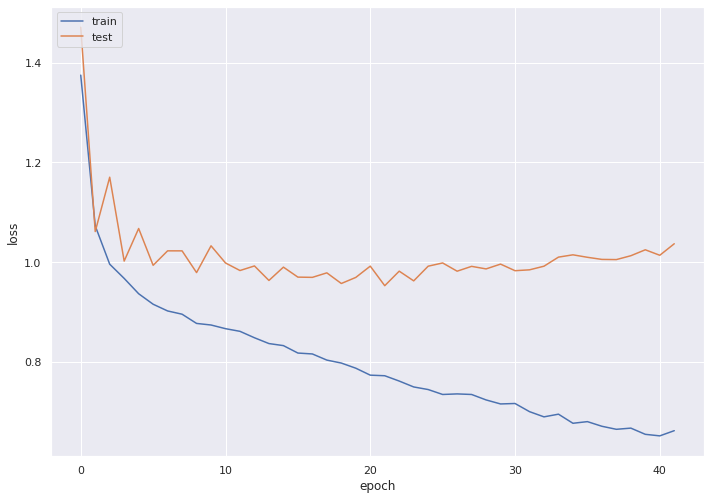

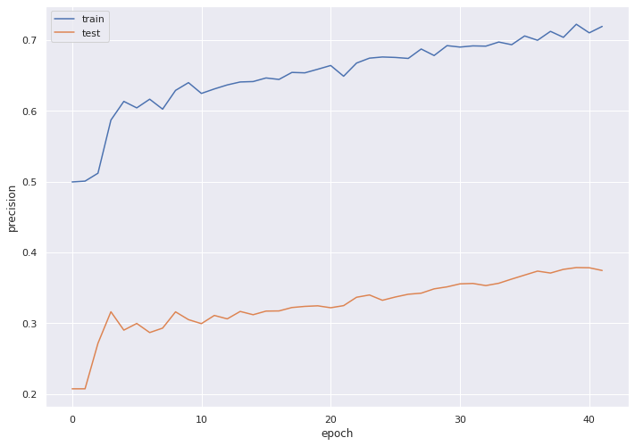

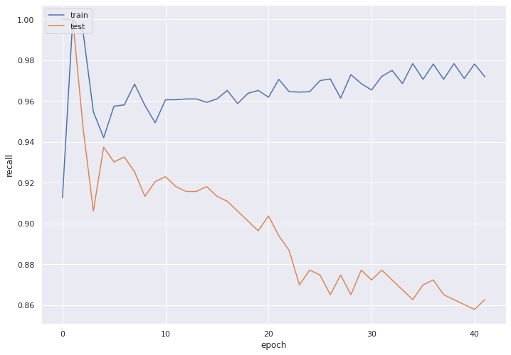

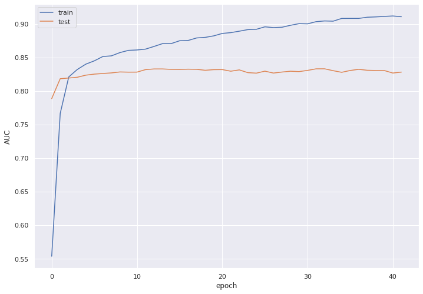

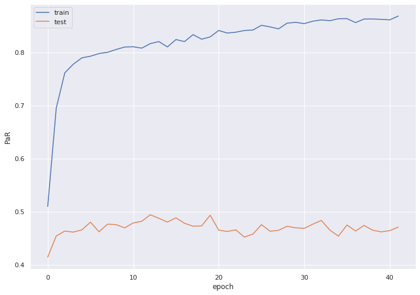

```python
plot_history(history, ['loss', 'precision', 'recall', 'AUC', 'PaR'])
```

```python
r, p, f1, cm, custom = get_model_metrics(model, X_train_np, y_train_np, 0.5, 1)
```

```
Recall: 0.98, Precision: 0.68, f1:0.8, custom metric:0.83:
```

```python
r, p, f1, cm, custom = get_model_metrics(model, X_test_np, y_test_np, 0.5, 1)
```

```
Recall: 0.89, Precision: 0.33, f1:0.48, custom metric:0.77:
```

```python
result = {'name': 'Early stop', 'recall' : r, 'precision': p, 'f1_score': f1, 'custom_metric': custom}
model_results.append(result)
```

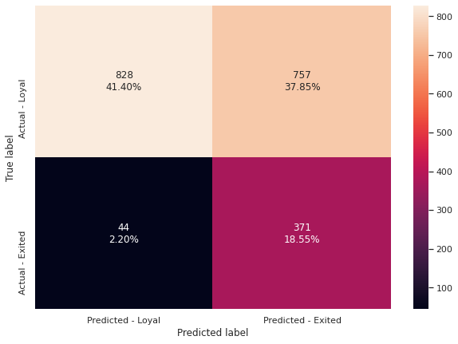

```python
make_confusion_matrix(cm)
```

Early stop improved recall, but precision degraded. Custom metric slightly improved. Overall quality slightly improved since number of detected Exiting customers improved. Let's try to find optimal threshold

```python
y_pred=model.predict(X_val_np)[:,0]
pr, rc, thresholds_keras = skmetrics.precision_recall_curve(y_val_np, y_pred)

#f1 = 2 * (pr * rc) / (pr + rc)
#idx = find_nearest(f1, f1.max())

new_th = find_best_threshold(y_val_np, y_pred)
idx = find_nearest(thresholds_keras, new_th)

print ("{} Precision={}, Recall={}, Threshold={}".format(idx, pr[idx], \
                  rc[idx], thresholds_keras[idx]))
```

```
1059 Precision=0.37901498929336186, Recall=0.8530120481927711, Threshold=0.6519231200218201
```

Let's see Optimal threshold on ROC-AUC and precision-recall curves

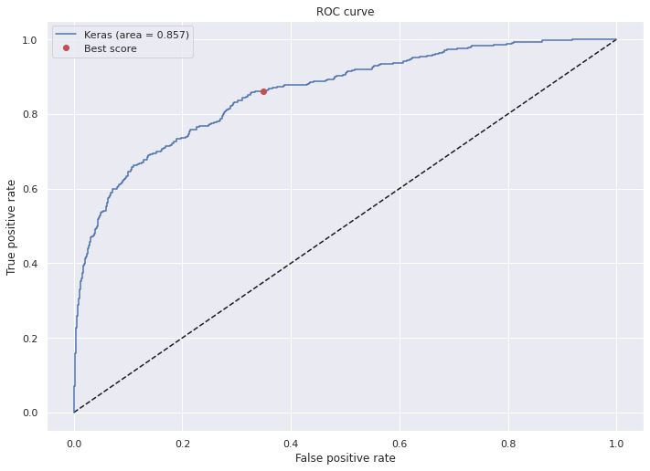

```python
plot_roc_auc(model, X_test_np, y_test_np, new_th)
```

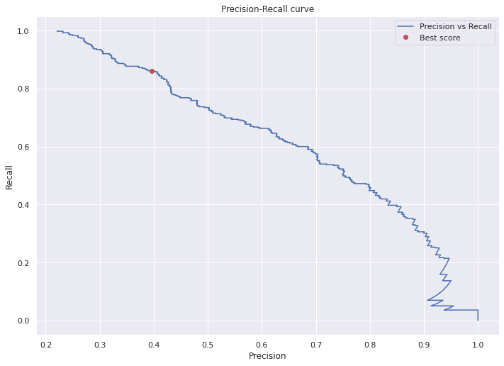

```python
plot_precision_recall(model, X_test_np, y_test_np, new_th)
```

```python
print('Test set')
print ('Metrics for default threshold:')
dummy = get_model_metrics(model, X_test_np, y_test_np, 0.5, 1)
print ('Metrics for new threshold ({0:.02}):'.format(new_th))
r, p, f1, cm, custom = get_model_metrics(model, X_test_np, y_test_np, new_th, 1)
```

```
Test set
Metrics for default threshold:
Recall: 0.89, Precision: 0.33, f1:0.48, custom metric:0.77:
Metrics for new threshold (0.65):
Recall: 0.86, Precision: 0.4, f1:0.54, custom metric:0.79:
```

```python
result = {'name': 'Early stop with modified threshold', 'recall' : r, 'precision': p, 'f1_score': f1, 'custom_metric': custom}
model_results.append(result)
```

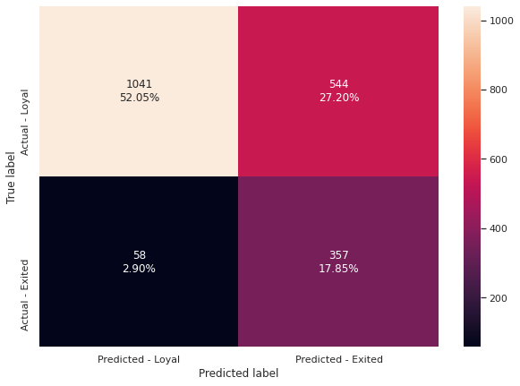

```python
make_confusion_matrix(cm)
```

## Learning rate adjustment

As mentioned earlier, loss function demonstrates oscilations which is a sign of leaning rate being too high. We can try to start reducing learning rate after certain epoch to supress oscilations

```python
from tensorflow.math import  exp

def lr_scheduler(epoch, lr):
  if epoch < 10:
    return lr
  elif epoch == 10:
    return lr * 0.5
  else:
    return lr * exp(-0.05)
```

```python
lr_cb = ks.callbacks.LearningRateScheduler(lr_scheduler)
callbacks = [lr_cb]
```

```python
model,history = buildNeuralNetwork(n_layers, n_nodes, activation, loss_f, optimizer, mult, batch,
                   epochs, X_train_np, y_train_np,
                   n_inputs, do_rate, callbacks, verbose)
```

```
Change LR from 0.0010000000474974513 to <tf.Variable 'learning_rate:0' shape=() dtype=float32, numpy=0.001>
```

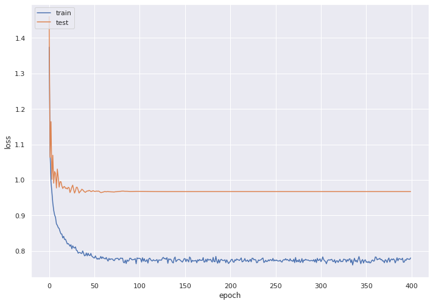

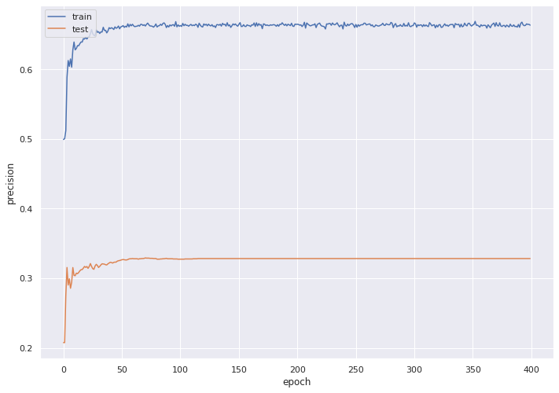

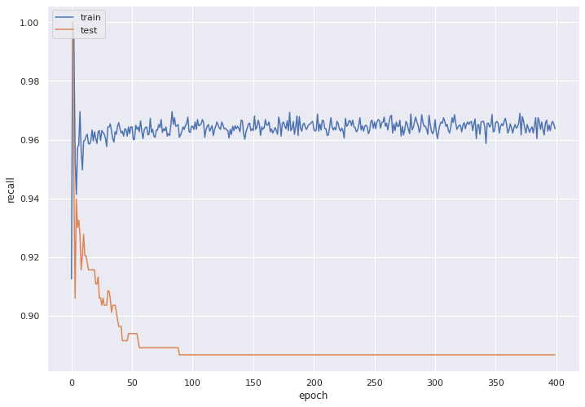

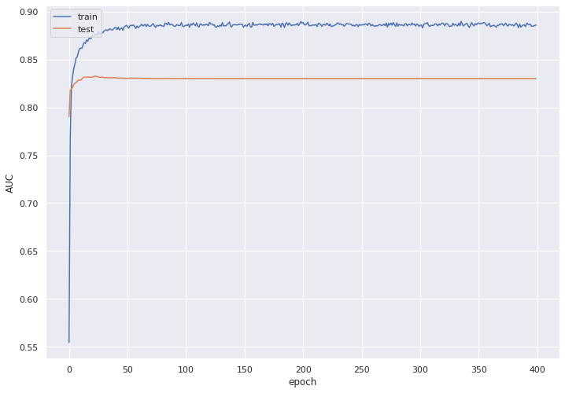

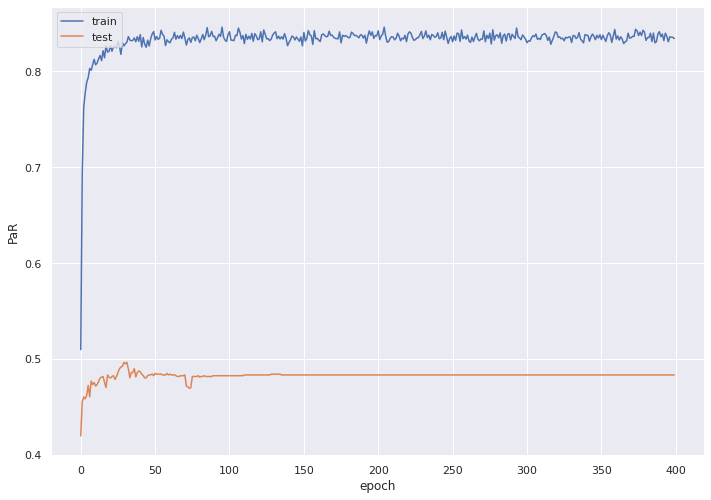

```python
plot_history(history, ['loss', 'precision', 'recall', 'AUC', 'PaR'])
```

Oscilation magnitude became significantly smaller. We can tell that the model obtained that way is more robust

```python
r, p, f1, cm, custom = get_model_metrics(model, X_train_np, y_train_np, 0.5, 1)
```

```
Recall: 0.97, Precision: 0.68, f1:0.8, custom metric:0.83:
```

```python
r, p, f1, cm, custom = get_model_metrics(model, X_test_np, y_test_np, 0.5, 1)
```

```
Recall: 0.89, Precision: 0.33, f1:0.49, custom metric:0.77:
```

```python
result = {'name': 'LR adjustment', 'recall' : r, 'precision': p, 'f1_score': f1, 'custom_metric': custom}
model_results.append(result)
```

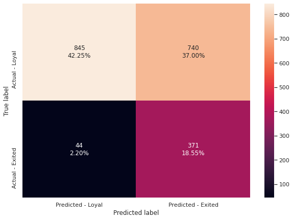

```python
make_confusion_matrix(cm)
```

Target metric didn't change, but more Exiting customers have been detected compared to initiala NN. Let's try to find optimal threshold

```python
y_pred=model.predict(X_val_np)[:,0]
pr, rc, thresholds_keras = skmetrics.precision_recall_curve(y_val_np, y_pred)

#f1 = 2 * (pr * rc) / (pr + rc)
#idx = find_nearest(f1, f1.max())

new_th = find_best_threshold(y_val_np, y_pred)
idx = find_nearest(thresholds_keras, new_th)

print ("{} Precision={}, Recall={}, Threshold={}".format(idx, pr[idx], \
                  rc[idx], thresholds_keras[idx]))
```

```
1034 Precision=0.372528616024974, Recall=0.8626506024096385, Threshold=0.626495897769928
```

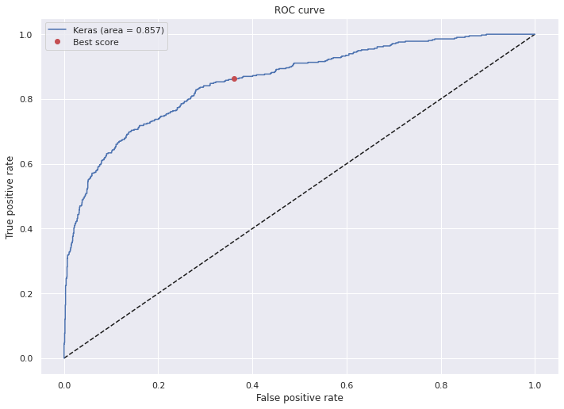

```python
plot_roc_auc(model, X_test_np, y_test_np, new_th)
```

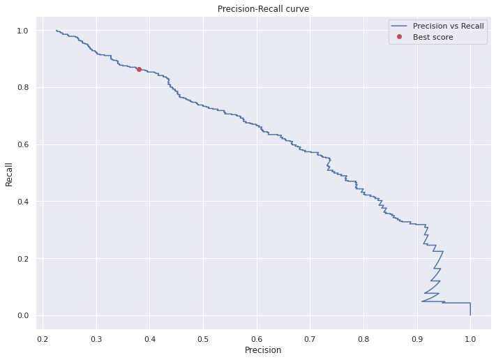

```python
plot_precision_recall(model, X_test_np, y_test_np, new_th)
```

```python
print('Test set')
print ('Metrics for default threshold:')
dummy = get_model_metrics(model, X_test_np, y_test_np, 0.5, 1)
print ('Metrics for new threshold ({0:.02}):'.format(new_th))
r, p, f1, cm, custom = get_model_metrics(model, X_test_np, y_test_np, new_th, 1)
```

```
Test set
Metrics for default threshold:
Recall: 0.89, Precision: 0.33, f1:0.49, custom metric:0.77:
Metrics for new threshold (0.63):
Recall: 0.86, Precision: 0.38, f1:0.53, custom metric:0.79:
```

```python
result = {'name': 'LR adjustment with modified threshold', 'recall' : r, 'precision': p, 'f1_score': f1, 'custom_metric': custom}
model_results.append(result)
```

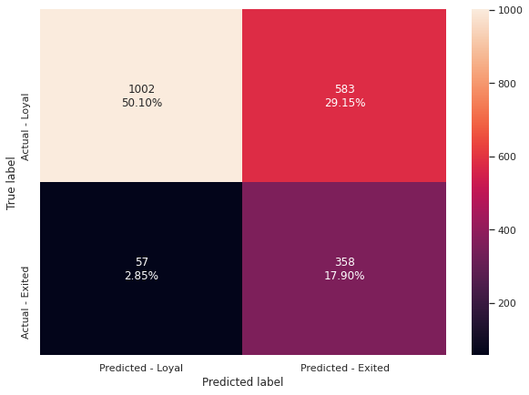

```python
make_confusion_matrix(cm)
```

With optimal threshold performance stays the same. Recall degraded, but preciion improved

## Early stop with Learning rate adjustment

Both early stop and learning rate adjustment improve model performance. Let's try them together

```python
lr_cb = ks.callbacks.LearningRateScheduler(lr_scheduler)
callbacks = [lr_cb, early_stop_cb]
```

```python
model,history = buildNeuralNetwork(n_layers, n_nodes, activation, loss_f, optimizer, mult, batch,
                   epochs, X_train_np, y_train_np,
                   n_inputs, do_rate, callbacks, verbose)
```

```
Change LR from 0.0010000000474974513 to <tf.Variable 'learning_rate:0' shape=() dtype=float32, numpy=0.001>
```

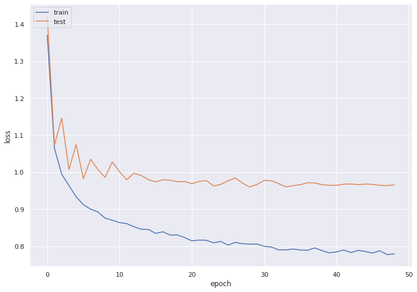

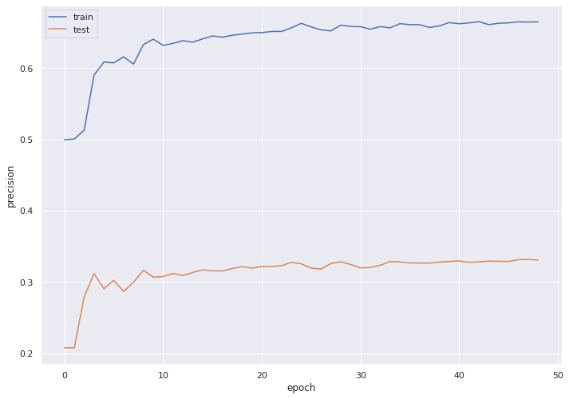

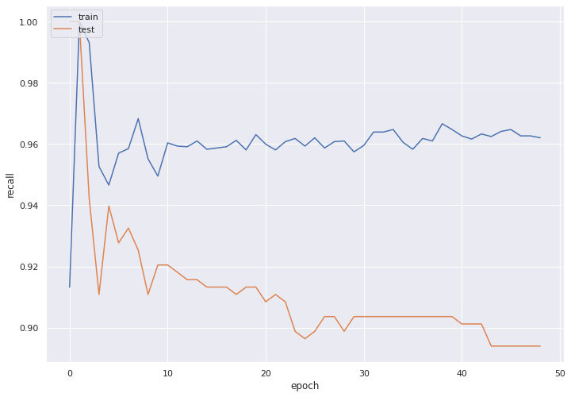

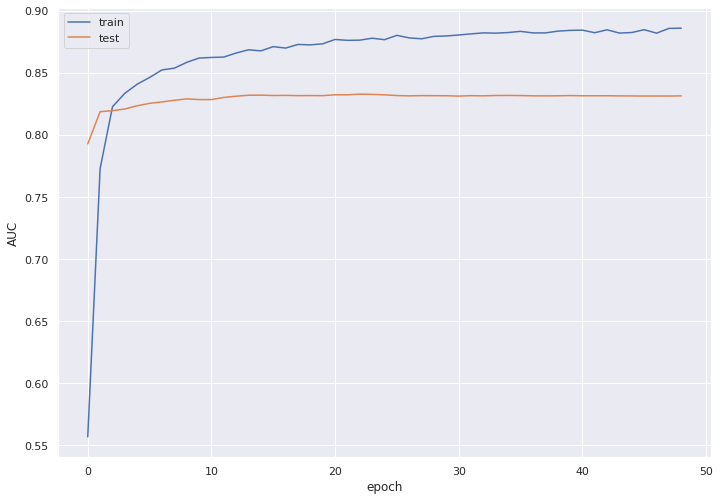

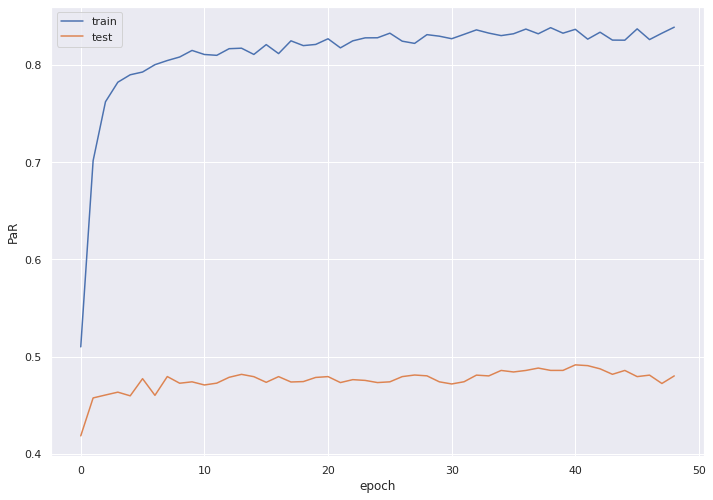

```python
plot_history(history, ['loss', 'precision', 'recall', 'AUC', 'PaR'])
```

```python
r, p, f1, cm, custom = get_model_metrics(model, X_train_np, y_train_np, 0.5, 1)
```

```
Recall: 0.96, Precision: 0.67, f1:0.79, custom metric:0.82:
```

```python
r, p, f1, cm, custom = get_model_metrics(model, X_test_np, y_test_np, 0.5, 1)
```

```
Recall: 0.89, Precision: 0.33, f1:0.48, custom metric:0.77:
```

```python
result = {'name': 'LR adjustment+Early stop', 'recall' : r, 'precision': p, 'f1_score': f1, 'custom_metric': custom}
model_results.append(result)
```

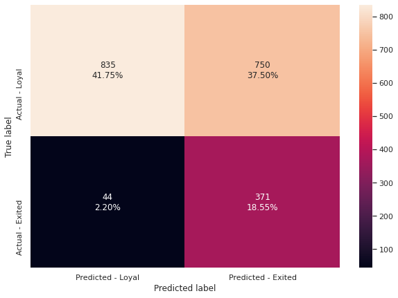

```python
make_confusion_matrix(cm)
```

Recall value is good and precision is OK compared to other models. Let's try to optimize threshold

```python
y_pred=model.predict(X_val_np)[:,0]
pr, rc, thresholds_keras = skmetrics.precision_recall_curve(y_val_np, y_pred)

#f1 = 2 * (pr * rc) / (pr + rc)
#idx = find_nearest(f1, f1.max())

new_th = find_best_threshold(y_val_np, y_pred)
idx = find_nearest(thresholds_keras, new_th)

print ("{} Precision={}, Recall={}, Threshold={}".format(idx, pr[idx], \
                  rc[idx], thresholds_keras[idx]))
```

```
957 Precision=0.35226179018286813, Recall=0.8819277108433735, Threshold=0.5786020755767822
```

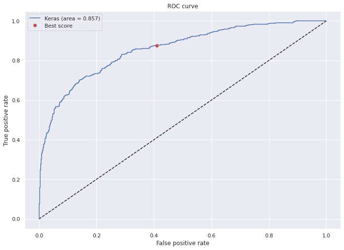

```python
plot_roc_auc(model, X_test_np, y_test_np, new_th)
```

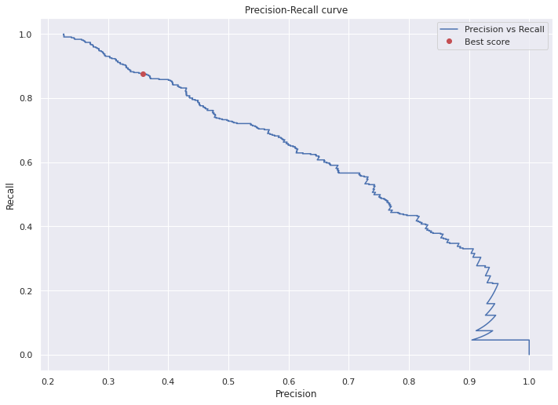

```python
plot_precision_recall(model, X_test_np, y_test_np, new_th)
```

```python
print('Test set')
print ('Metrics for default threshold:')
dummy = get_model_metrics(model, X_test_np, y_test_np, 0.5, 1)
print ('Metrics for new threshold ({0:.02}):'.format(new_th))
r, p, f1, cm, custom = get_model_metrics(model, X_test_np, y_test_np, new_th, 1)
```

```
Test set
Metrics for default threshold:
Recall: 0.89, Precision: 0.33, f1:0.48, custom metric:0.77:
Metrics for new threshold (0.58):
Recall: 0.87, Precision: 0.36, f1:0.51, custom metric:0.78:
```

```python
result = {'name': 'LR adjustment + Early stop with modified threshold', 'recall' : r, 'precision': p, 'f1_score': f1, 'custom_metric': custom}
model_results.append(result)
```

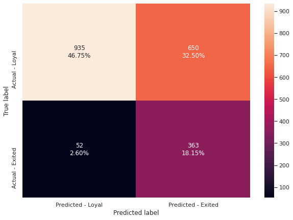

```python
make_confusion_matrix(cm)
```

Recall slightly degraded and precision slightly improved

# Model Performance Evaluation

- Evaluate the model on different performance metrics and comment on the performance and scope of improvement

```python
result_df = pd.DataFrame(data=model_results)
```

```python
result_df
```

|  | name | recall | precision | f1_score | custom_metric |
| --- | --- | --- | --- | --- | --- |
| 0 | First try | 0.710843 | 0.512153 | 0.595358 | 0.748133 |
| 1 | First try with modified threshold | 0.845783 | 0.381107 | 0.525449 | 0.777315 |
| 2 | Early stop | 0.893976 | 0.328901 | 0.480881 | 0.770116 |
| 3 | Early stop with modified threshold | 0.860241 | 0.396226 | 0.542553 | 0.792421 |
| 4 | LR adjustment | 0.893976 | 0.333933 | 0.486239 | 0.773692 |
| 5 | LR adjustment with modified threshold | 0.862651 | 0.380446 | 0.528024 | 0.785826 |
| 6 | LR adjustment+Early stop | 0.893976 | 0.330955 | 0.483073 | 0.771589 |
| 7 | LR adjustment + Early stop with modified thres... | 0.874699 | 0.358342 | 0.508403 | 0.779768 |

- Threshold optimizatios doesn't add much value to our custom metric. It just rundomly increse recall and decrese precision or the othe way around. Since the behaviour of this technique is unpredictable for this type of problem, we won't consider models with modified threshold
- Neural network with learning rate adjustment and early stop has a high recall. It also stops at the minimum of the loss function for validation set and has a very small loss function oscilation magnitude at the end of the curve, which is a sign of good fit. We would recommend this model

Further improvement model can include:

- Hyperparameter tuning for loss functions, number of nodes/layers, activation functios, dropout ratio
- Different weight initialization techniques
- Seeding random number generators with different values to find better a local minimum
- Adopt global otimization technique like Similated annealing to find a global minimum

# Conclusion and key takeaways

- NN performance is sensetive to different parametrs like number of layers and nodes, activation and loss functios
- Divergence of training and validataion loss functions can be fixed by adding layers and nodes. For fine tuning add nodes, for coarse tuning add layers
- NN training results are sensetive to initial weigh, which means it's a global optimization problem
- Callbacks like **Learning rate scheduling** and **early stop** help to improve NN training proces

# End of the project. Thank you

# Appendix: Using simulated annealing technique for NN training

As mentioned earlier, some kind of golbal optimization can be tried for NN training. Here is my attempt to implement global optimization algorithm called Simulated Annealing. There are many resources on the Web explaining Simulated Annealing algorithm. For example, this one: https://www.theprojectspot.com/tutorial-post/simulated-annealing-algorithm-for-beginners/6

Gradient descent is often explained as a behavior of a solid ball going down from the hill to the bottom of the valley. To explany a concept of global optimiztion we can use a model of elastic ball that can also go downhill, but it can also bounce. If there are multiple hills and valleys in the multidimentional space, the elastic ball will be able to bounce out of the shallow valley and find a deeper, more optimal, one.

In the beginning the bouncing energy of the ball is high and it's mostly bouncing. Then it combines bouncing and gradient descent behaviour. At the end of the optimization it only descends.

```python
indent = 0
mutation_ratio = 0.1
mutator = (lambda x: x if np.random.rand() > mutation_ratio else 0.0)

def mutate(mutation_ratio, weights):
  global indent

  result = []

  new_weights = weights
  indent += 1
  if type(weights) in [list]:
    #print('.'* indent, type(weights), len(weights))
    for w in weights:
      new_w = mutate(mutation_ratio, w)
      result.append(new_w)
  elif type(weights) in [np.ndarray]:
    #print('.'* indent, type(weights), len(weights), weights.shape)
    if len(weights.shape) == 1:
      #print('---',weights)
      m = map(mutator, weights)
      result=np.array(list(m))
      #print('.'* indent, 'result 1:',  type(result), len(result), result.shape)
      #print ('+++',result)
    else:
      result = []
      for w in weights:
        new_w = mutate(mutation_ratio, w)
        result.append(new_w)
      result=np.array(result)
      #print('.'* indent, 'result 2:',  type(result), len(result), result.shape)
  else:
    1
  indent -= 1
  return result
```

The code above implements a function mutate() which is a simulation of a single bounce. I changes randomly zeros 10% of model weights, which leads (in most cases) to the increas of model loss function

The code below implements a custom callback class with simulated annealing functionality. Parameter T is a "Temperature" parameter; it can also be explained as ball's bouncing energy. The higher T, the higher is a probability to bounce.

In the beginning of every epoch the ball makes an attempt to bounce, i.e. we zero 10% of the model weights. If new loss function is lower than loss function of previous epoch, we accept this bounce. If new loss function is higher, we calculate a probabity of that bounce and compare with a rundom number. If probabity is higher than a random number, we accept the bounce even if it leads to the increase of loss function. Othervise, we decline bounce and perform gradient step.

During the training we save weights for the best val_loss and restore them at the end of training

```python
class SaCallback(ks.callbacks.Callback):
    def on_train_begin(self, logs=None):
        self.last_loss = 0.0
        self.T=50.0
        self.epoch_per_temp = 10
        self.temp_change_rate = 0.025
        self.sample_weight = np.ones(shape=(len(y_train_np),))
        self.sample_weight[y_train_np == 1] = 4

        self.val_sample_weight = np.ones(shape=(len(y_val_np),))
        self.val_sample_weight[y_val_np == 1] = 4

        self.min_delta = 1e-3

        self.prev_bounce_epoch = 0
        self.prev_improvement_epoch = 0
        self.patience = 15
        self.best_loss = 1e300
        self.best_weights = None

        self.descend_after_bounce = 1

        return

    def on_train_end(self, logs=None):
        print ("T at the end of training is {0:.2}".format(self.T))
        self.model.set_weights(self.best_weights)
        return

    def on_epoch_begin(self, epoch, logs=None):
      if epoch % 100 == 0:
        print ("Epoch # {}".format(epoch))
      if(self.can_mutate(epoch)):
        self.change_model()
        action = 'bounce'
        change, change_loss = self.accept_chage()
        if change == 0:
          action = 'descend'
          self.model.set_weights(self.save_weights)

        #print("Begin {0} val_loss = {1:.4}: {2} T:{3:.2} changed loss: {4:.4}".format(epoch, self.last_loss, action, self.T, change_loss))
        if (action == 'bounce'):
          self.prev_bounce_epoch = epoch
          self.T = self.T * (1 - self.temp_change_rate)

      return

    def on_epoch_end(self, epoch, logs=None):
      if logs['val_loss'] < self.last_loss:
        self.prev_improvement_epoch = epoch

      self.last_loss = logs['val_loss']
      if (epoch % self.epoch_per_temp == self.epoch_per_temp - 1):
        self.T = self.T * (1 - self.temp_change_rate)

      if (epoch > self.patience and (epoch - self.prev_bounce_epoch) > self.patience):
        lr = (K.eval(self.model.optimizer.lr))
        lr *= 0.999
        if lr < 1e-5:
          lr = 1e-5
        #print ("Change LR to {}".format(lr))
        self.model.optimizer.learning_rate.assign(lr)

      if self.last_loss < self.best_loss:
        self.best_loss = self.last_loss
        self.best_weights = self.model.get_weights()

      #if (epoch - self.prev_improvement_epoch > self.patience):
      #  self.model.stop_training = True
      return

    def on_test_begin(self, logs=None):
        return

    def on_test_end(self, logs=None):
        return

    def on_predict_begin(self, logs
                         =None):
        return

    def on_predict_end(self, logs=None):
        return

    def on_train_batch_begin(self, batch, logs=None):
        return

    def on_train_batch_end(self, batch, logs=None):
        return

    def on_test_batch_begin(self, batch, logs=None):
        return

    def on_test_batch_end(self, batch, logs=None):
        return

    def on_predict_batch_begin(self, batch, logs=None):
        return

    def on_predict_batch_end(self, batch, logs=None):
        return

    def can_mutate(self, epoch):
      if (epoch - self.prev_bounce_epoch < self.descend_after_bounce):
        return 0
      return 1

    def accept_chage(self):
      y_pred = self.model.predict(X_val_np)
      loss = self.model.loss(y_val_np, y_pred, self.val_sample_weight)
      dL = loss - self.last_loss

      #not interested in very low bounce
      if (abs(dL) < self.min_delta):
        return 0, loss

      probability = exp(-dL/self.T)
      if (probability >= np.random.rand()):
        return 1, loss

      return 0, loss

    def change_model(self):
      self.save_weights = self.model.get_weights()
      new_weights = mutate(mutation_ratio, self.save_weights)
      self.model.set_weights(new_weights)
      return
```

```python
#lr_cb = ks.callbacks.LearningRateScheduler(lr_scheduler)
#callbacks = [lr_cb, early_stop_cb]
callbacks = [SaCallback()]
```

```python
epochs = 2500
optimizer = ks.optimizers.Adam()
model,history = buildNeuralNetwork(n_layers, n_nodes, activation, loss_f, optimizer, mult, batch,
                   epochs, X_train_np, y_train_np,
                   n_inputs, do_rate, callbacks, verbose)
```

```
Change LR from 0.001 to <tf.Variable 'learning_rate:0' shape=() dtype=float32, numpy=0.001>
Epoch # 0
Epoch # 100
Epoch # 200
Epoch # 300
Epoch # 400
Epoch # 500
Epoch # 600
Epoch # 700
Epoch # 800
Epoch # 900
Epoch # 1000
Epoch # 1100
Epoch # 1200
Epoch # 1300
Epoch # 1400
Epoch # 1500
Epoch # 1600
Epoch # 1700
Epoch # 1800
Epoch # 1900
Epoch # 2000
Epoch # 2100
Epoch # 2200
Epoch # 2300
Epoch # 2400
T at the end of training is 0.0011
```

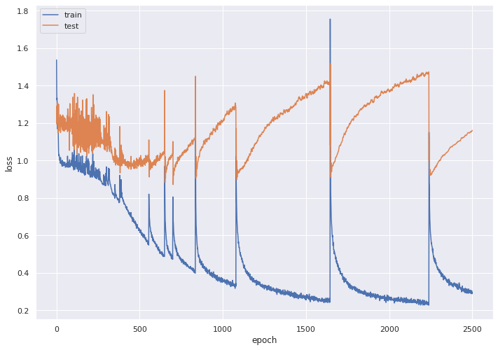

```python
plot_history(history, ['loss'])
```

We can see several training period on the training history plots:

1. 0 - 250 bounces are dominating
2. 250-600 gradient descend with frequent bouncing. Loss function is decreasing for both training and validation data.
3. 600+ bounces become less and less frequent. Model becomes overtrained: after each bounce training loss function rapidly decreases while validation loss function rapidly increases

```python
r, p, f1, cm, custom = get_model_metrics(model, X_test_np, y_test_np, 0.5, 1)
```

```
Recall: 0.8, Precision: 0.43, f1:0.56, custom metric:0.78:
```

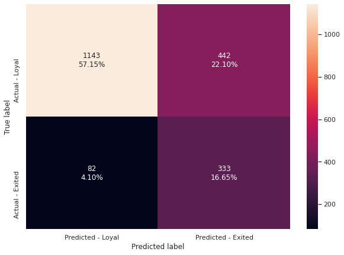

```python
make_confusion_matrix(cm)
```